# w1_gradient_discent

## WEEK 1

## MSE and Gradient Descent

```python
import numpy as np
import matplotlib.pyplot as plt
from sklearn.linear_model import LinearRegression
from sklearn.metrics import mean_squared_error
import random
```

## Q3

```python
#generate data x,y
def generate_data(n, j , sigma, beta_coeffs,):
    X = np.random.normal(0, 1, n)
    y = np.zeros(n)
    X = np.array([X**(i+1) for i in range(j)]).T
    y = np.matmul(X,beta_coeffs)
    y = y + np.random.normal(0, sigma, n)
    return X,y


#calculate mse for train and test data
def calculate_mses_and_optimal_p(p_range, j, sigma, beta_coeffs, iterations=1000):
    train_mses = np.zeros((len(p_range),))
    test_mses = np.zeros((len(p_range),))

    for iteration in range(iterations):
        X, y = generate_data(n, j, sigma, beta_coeffs)
        train_size = int(0.7 * len(X))
        X_train, y_train = X[:train_size], y[:train_size]
        X_test, y_test = X[train_size:], y[train_size:]

        for p_idx, p in enumerate(p_range):
            X_train_p = X_train[:, :p]
            X_test_p = X_test[:, :p]
            model = LinearRegression().fit(X_train_p, y_train)
            y_train_pred = model.predict(X_train_p)
            y_test_pred = model.predict(X_test_p)

            train_mse = mean_squared_error(y_train, y_train_pred)
            test_mse = mean_squared_error(y_test, y_test_pred)

            train_mses[p_idx] += train_mse
            test_mses[p_idx] += test_mse

    train_mses /= iterations
    test_mses /= iterations

    optimal_p_train = np.argmin(train_mses) + 1
    optimal_p_test = np.argmin(test_mses) + 1

    return train_mses, test_mses, optimal_p_train, optimal_p_test
```

```python
n = 20
max_p = 25
j = 25
sigmas = [0.05, 0.3, 0.5, 0.8, 1]
beta_coeffs = np.array([(0.5 + 0.5 * (i + 1) / 25) for i in range(j)])
p_range = range(1, max_p + 1)
```

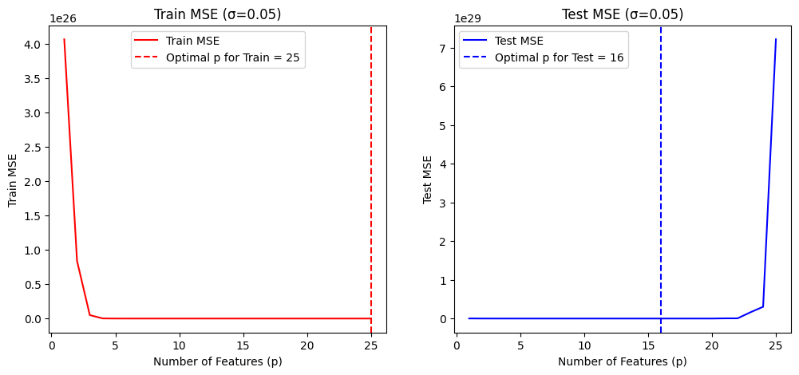

```
The estimated Train MSE with σ=0.05: [4.06266896e+26 8.38194731e+25 4.98321730e+24 1.81540522e+23
 9.73000836e+21 5.62768804e+20 1.95068645e+18 1.09483831e+16
 2.47466593e+14 5.34742870e+12 3.22591907e+10 1.50768993e+08
 2.66779198e-04 5.88363671e-02 1.78982156e-03 4.66799154e-02
 3.34572327e-03 4.42771777e-04 4.44211127e-05 2.81783581e-04
 2.48698450e-04 8.84690390e-04 5.78175658e-04 6.38803913e-05
 3.99881957e-05]
Optimal p for Train MSE with σ=0.05: 25
The estimated Test MSE with σ=0.05: [1.90508285e+26 5.13350806e+25 9.32345404e+24 1.49334044e+24
 4.14297919e+23 2.84450605e+23 2.18225750e+23 1.85148363e+23
 1.72522076e+23 1.72245461e+23 1.69880293e+23 1.85746653e+23
 2.24082273e+23 1.76117775e+23 1.76480545e+23 1.66345192e+23
 5.91773367e+23 4.65066390e+23 1.38017505e+25 1.13257924e+25
 4.42397712e+26 4.96246006e+26 1.60249853e+28 3.03644671e+28
 7.21182228e+29]
Optimal p for Test MSE with σ=0.05: 16
```

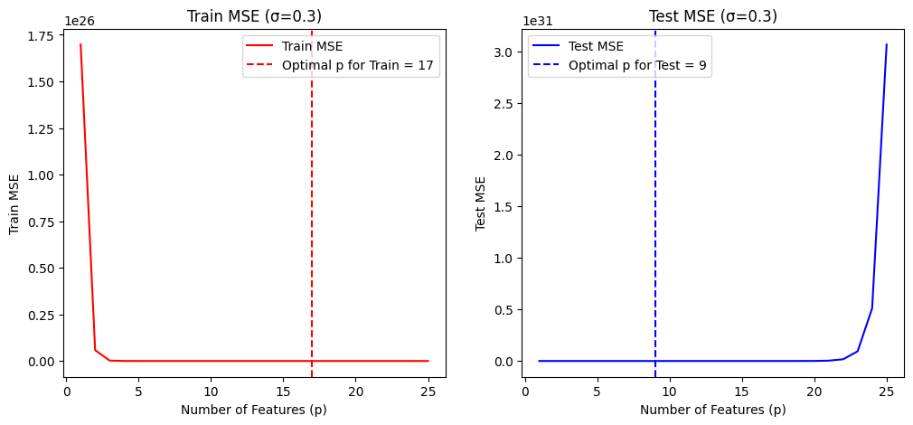

```
The estimated Train MSE with σ=0.3: [1.69791645e+26 5.82655895e+24 2.21533012e+23 1.17218450e+22
 5.24660439e+20 2.74367818e+19 1.55869362e+18 4.69279222e+16
 9.37307947e+14 1.22859706e+13 1.23994213e+11 9.84986571e+08
 1.82071518e-04 9.47704026e-04 4.85472649e-04 1.67465646e-04
 4.36338787e-05 3.21008951e-04 2.73646778e-04 4.53861272e-03
 9.61297818e-04 3.97267860e-04 5.82245856e-04 9.73987851e-04
 1.15950673e-03]
Optimal p for Train MSE with σ=0.3: 17
The estimated Test MSE with σ=0.3: [8.54173026e+26 2.43427384e+26 6.34337444e+25 2.07281833e+25
 8.66900909e+24 5.43194380e+24 2.86581921e+24 6.06579065e+24
 5.80718606e+23 2.05207015e+25 1.22025250e+25 1.38982943e+26
 2.86940844e+26 2.47044568e+26 1.19437578e+26 1.71653753e+26
 1.39197438e+26 4.01802886e+26 1.42205905e+27 6.47067412e+27
 3.35113661e+28 1.69154480e+29 9.43715894e+29 5.10370074e+30
 3.06530338e+31]
Optimal p for Test MSE with σ=0.3: 9
```

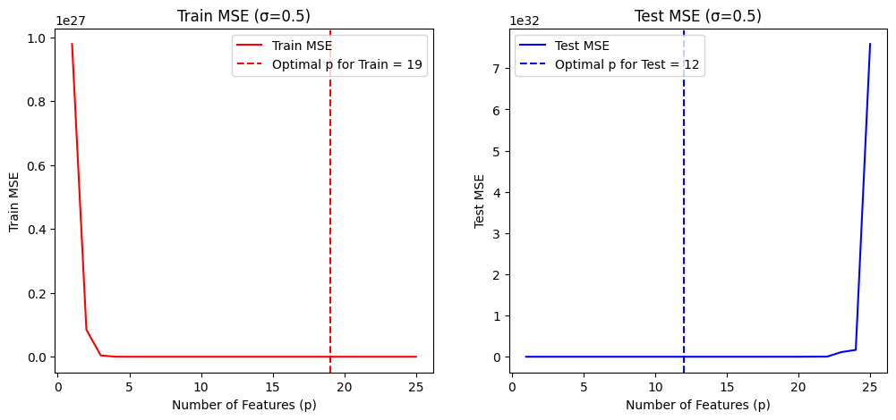

```
The estimated Train MSE with σ=0.5: [9.78569844e+26 8.47197358e+25 4.25605452e+24 1.46990703e+23
 6.44001482e+21 2.57307869e+20 1.21399455e+19 1.25513933e+18
 2.91983038e+16 3.34958706e+14 2.59734106e+12 1.12617709e+09
 1.35759159e-03 5.57231220e-04 1.73825467e-03 6.10559706e-04
 5.68705155e-04 1.07809379e-03 5.37372377e-04 1.69580970e-03
 9.15335231e-03 3.51883698e-03 1.91245043e-03 2.90637807e-03
 5.12192552e-03]
Optimal p for Train MSE with σ=0.5: 19
The estimated Test MSE with σ=0.5: [3.76958968e+26 5.61213002e+25 1.16042308e+25 8.50195190e+24
 9.09458179e+24 8.31921223e+24 8.30701181e+24 7.77199949e+24
 8.11546417e+24 8.24093080e+24 7.47505848e+24 6.60027479e+24
 1.11470061e+25 1.01617261e+25 1.74554941e+25 2.87197391e+25
 1.19766154e+26 2.70353510e+26 3.41715631e+27 7.00000683e+27
 1.80205811e+29 3.03646298e+29 1.13631772e+31 1.65929537e+31
 7.58615738e+32]
Optimal p for Test MSE with σ=0.5: 12
```

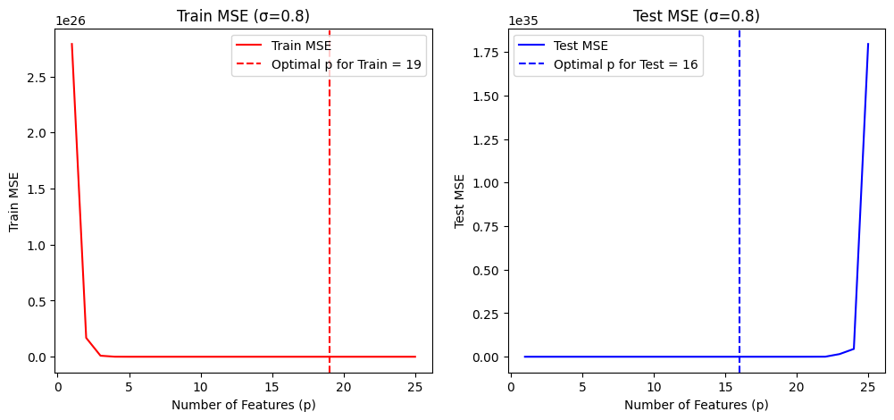

```
The estimated Train MSE with σ=0.8: [2.78982436e+26 1.68564960e+25 9.40088336e+23 5.35391329e+22
 1.92751382e+21 1.07361118e+20 4.86581244e+18 1.89647421e+17
 1.50057061e+16 4.50259691e+14 3.10280542e+12 1.61427843e+11
 3.00386277e-03 1.53386445e-03 6.88882605e-02 1.35249493e-02
 1.09821847e-03 9.34187110e-04 7.84285781e-04 2.60168341e-03
 2.13712156e-03 3.23056539e-03 5.19365275e-03 6.66946377e-03
 8.56347815e-03]
Optimal p for Train MSE with σ=0.8: 19
The estimated Test MSE with σ=0.8: [1.34317426e+28 1.32130896e+28 1.30972306e+28 1.28917548e+28
 1.28508388e+28 1.27949184e+28 1.27576744e+28 1.27436982e+28
 1.27326910e+28 1.27313240e+28 1.27261032e+28 1.27273075e+28
 1.27211241e+28 1.27152874e+28 1.27268893e+28 1.27037379e+28
 1.43477901e+28 1.59696377e+28 1.56657285e+29 3.69331953e+29
 1.41794007e+31 3.89257388e+31 1.53933960e+33 4.49724077e+33
 1.79586586e+35]
Optimal p for Test MSE with σ=0.8: 16
```

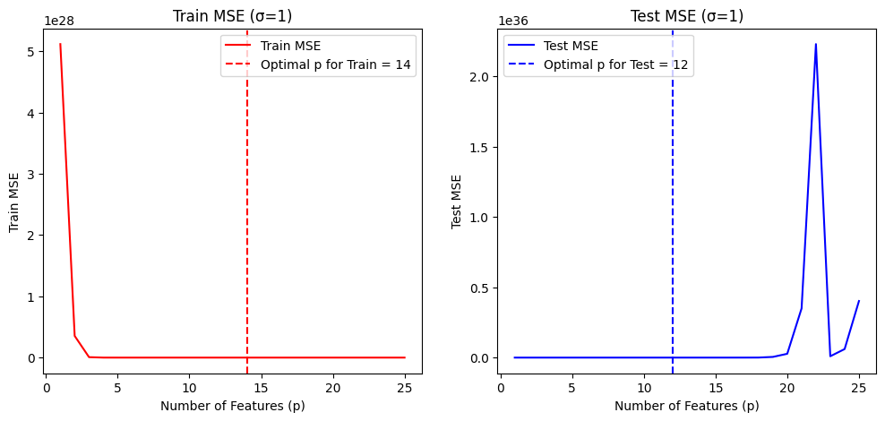

```
The estimated Train MSE with σ=1: [5.11495621e+28 3.53563819e+27 7.42074556e+25 1.67103272e+24
 2.74493525e+22 2.62882273e+20 1.84802332e+18 6.39756437e+16
 1.70245393e+15 4.02987529e+13 4.97057953e+11 1.94554971e+09
 6.58138156e-02 6.16194513e-03 5.85359000e-01 8.13458098e-02
 8.81204652e-03 1.39018584e-01 1.41375887e-02 4.34899898e-02
 6.29688188e-02 8.41152839e-02 2.66430506e-02 5.22210488e-02
 1.21472383e-02]
Optimal p for Train MSE with σ=1: 14
The estimated Test MSE with σ=1: [1.85091581e+29 1.24972482e+29 3.42241313e+28 1.14536556e+28
 6.42897346e+27 3.72483395e+27 1.71613694e+27 9.46612680e+26
 8.10079326e+26 3.86835056e+26 2.52908530e+26 2.09180567e+26
 9.30318505e+27 4.68624504e+28 8.00272299e+29 4.11320144e+30
 6.49746233e+31 3.43407082e+32 4.91842408e+33 2.71885265e+34
 3.50071475e+35 2.22914837e+36 9.62189943e+33 6.06870499e+34
 4.02404217e+35]
Optimal p for Test MSE with σ=1: 12
```

```python
for sigma in sigmas:
    X, y = generate_data(n, j, sigma, beta_coeffs)
    train_mses, test_mses, optimal_p_train, optimal_p_test = calculate_mses_and_optimal_p(p_range, j, sigma, beta_coeffs, iterations=1000)

    # Plotting
    fig, ax = plt.subplots(1, 2, figsize=(12, 5))
    ax[0].plot(p_range, train_mses, label='Train MSE', color='r')
    ax[0].axvline(x=optimal_p_train, color='r', linestyle='--',
                  label=f'Optimal p for Train = {optimal_p_train}')
    ax[0].set_xlabel('Number of Features (p)')
    ax[0].set_ylabel('Train MSE')
    ax[0].set_title(f'Train MSE (σ={sigma})')
    ax[0].legend()

    ax[1].plot(p_range, test_mses, label='Test MSE', color='b')
    ax[1].axvline(x=optimal_p_test, color='b', linestyle='--',
                  label=f'Optimal p for Test = {optimal_p_test}')
    ax[1].set_xlabel('Number of Features (p)')
    ax[1].set_ylabel('Test MSE')
    ax[1].set_title(f'Test MSE (σ={sigma})')
    ax[1].legend()
    plt.show()

    print(f"The estimated Train MSE with σ={sigma}: {train_mses}")
    print(f"Optimal p for Train MSE with σ={sigma}: {optimal_p_train}")

    print(f"The estimated Test MSE with σ={sigma}: {test_mses}")
    print(f"Optimal p for Test MSE with σ={sigma}: {optimal_p_test}")
```

But for the Test MSE curve, the curve initially decreasing and then increasing, indicaing the overfitting for large p.

The discrepancy between the optimal p for training and testing suggests that some features are capturing noise, which benefits the training MSE but harms the test MSE.

## Q4

```python
from sklearn.model_selection import LeaveOneOut
from sklearn.preprocessing import PolynomialFeatures
import statsmodels.api as sm
import pandas as pd
```

```python
def generate_data(n, seed):
    np.random.seed(seed)
    x = np.random.normal(0, 1, n)
    e = np.random.normal(0, 1, n)
    y = x - 2*(x**2) + e
    return x, y

def loocv_errors(x, y):
    loocv = LeaveOneOut()
    models_mse = {}
    degrees = [1, 2, 3, 4]
    labels = ['Linear', 'Quadratic', 'Cubic', 'Quartic']

    for degree, label in zip(degrees, labels):
        model_mse = []
        for train_index, test_index in loocv.split(x):
            X_train, X_test = x[train_index], x[test_index]
            y_train, y_test = y[train_index], y[test_index]

            poly = PolynomialFeatures(degree)
            X_train_poly = poly.fit_transform(X_train[:, np.newaxis])
            X_test_poly = poly.transform(X_test[:, np.newaxis])

            model = LinearRegression().fit(X_train_poly, y_train)

            y_pred = model.predict(X_test_poly)
            mse = mean_squared_error(y_test, y_pred)
            model_mse.append(mse)

        models_mse[label] = np.mean(model_mse)

    return models_mse
```

```python
# (a)
x, y = generate_data(100, seed=0)
loocv_mse_a = loocv_errors(x, y)
loocv_mse_a
```

```
{'Linear': 8.888205832586202,
 'Quadratic': 1.116153188977269,
 'Cubic': 1.162225880390323,
 'Quartic': 1.147147943009142}
```

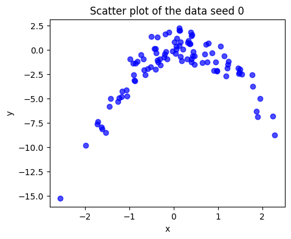

```python
plt.figure(figsize=(5, 4))
plt.scatter(x, y, alpha=0.7, color='b')
plt.xlabel('x')
plt.ylabel('y')
plt.title('Scatter plot of the data seed 0')
plt.show()
```

```python
# (b)
x_1, y_1 = generate_data(100, seed=1)
loocv_mse_b = loocv_errors(x_1, y_1)
loocv_mse_b
```

```
{'Linear': 6.260764331604616,
 'Quadratic': 0.9142897072803663,
 'Cubic': 0.9268768781648804,
 'Quartic': 0.8669116865881088}
```

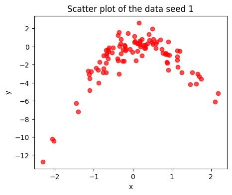

```python
plt.figure(figsize=(5, 4))
plt.scatter(x_1, y_1, alpha=0.7, color='r')
plt.xlabel('x')
plt.ylabel('y')
plt.title('Scatter plot of the data seed 1')
plt.show()
```

The result for seed 1 is different fron that of seed 0.

```python
# (c)
loocv_mse_a
```

```
{'Linear': 8.888205832586202,
 'Quadratic': 1.116153188977269,
 'Cubic': 1.162225880390323,
 'Quartic': 1.147147943009142}
```

```python
# (d)
def fit_polynomial_model(x, y, degree):
    poly_features = PolynomialFeatures(degree=degree)
    X_poly = poly_features.fit_transform(x.reshape(-1, 1))
    model = sm.OLS(y, X_poly).fit()
    return model.summary()

def compare_model_summaries(n, degrees, seeds):
    summaries = {}
    for seed in seeds:
        x, y = generate_data(n, seed)
        summaries[seed] = {}
        for degree in degrees:
            summary = fit_polynomial_model(x, y, degree)
            df_summary = pd.DataFrame(summary.tables[1].data)
            df_summary.columns = df_summary.iloc[0]
            df_summary = df_summary.drop(0)
            summaries[seed][f'Model degree {degree}'] = df_summary.iloc[:, :5]

    return summaries
```

```python
n = 100
degrees = [1, 2, 3, 4]
seeds = [0]

model_summaries = compare_model_summaries(n, degrees, seeds)

for seed in seeds:
    print(f"Results for seed {seed}:")
    for degree in degrees:
        print(f"\nPolynomial degree {degree}:")
        print(model_summaries[seed][f'Model degree {degree}'])
    print("\n" + "#" * 80 + "\n")
```

```
Results for seed 0:

Polynomial degree 1:
0               coef    std err          t   P>|t|
1  const     -1.9487      0.290     -6.726   0.000
2     x1      0.8650      0.287      3.015   0.003

Polynomial degree 2:
0               coef    std err          t   P>|t|
1  const      0.1427      0.132      1.079   0.283
2     x1      1.1230      0.104     10.829   0.000
3     x2     -2.0668      0.080    -25.700   0.000

Polynomial degree 3:
0               coef    std err          t   P>|t|
1  const      0.1432      0.133      1.077   0.284
2     x1      1.1626      0.195      5.975   0.000
3     x2     -2.0668      0.081    -25.575   0.000
4     x3     -0.0148      0.061     -0.240   0.810

Polynomial degree 4:
0               coef    std err          t   P>|t|
1  const      0.2399      0.153      1.563   0.121
2     x1      1.1207      0.197      5.691   0.000
3     x2     -2.3116      0.212    -10.903   0.000
4     x3      0.0049      0.063      0.078   0.938
5     x4      0.0556      0.045      1.248   0.215

################################################################################
```

For the linear model (degree 1), the constant and the coefficient of the linear term are significantly different from zero at 5% level.

For the quadratic model (degree 2), which is the true model, both the linear and quadratic terms are significant at 5% level, and the constant term is not significant, which matches the data generation process.

For the cubic (degree 3) and quartic (degree 4) models, only the the linear and quadratic terms are significant at 5% level. The constant and additional higher-order terms do not show significance, suggesting they do not contribute to explaining the variation in the dependent variable.